# RCT Historical Validation — Reproducibility Figures

This notebook reproduces **Figure 1**, **Table 2**, and **Table 3** from the paper.

- **Figure 1**: Pre-publication community sentiment — responders vs non-responders for 6 drugs
- **Table 2**: Data sources by drug (database, window, post/user/report counts)
- **Table 3**: Per-drug response composition with Wilson 95% CIs and binomial test p-values

**Method**: For each drug, we extract all treatment-sentiment reports from r/covidlonghaulers posts dated *before* the relevant clinical trial published. Each user contributes one data point per drug (best-report dedup: positive > mixed > neutral > negative; strong > moderate > weak tiebreak). We then test whether the proportion of responders (positive sentiment) differs from 50%.

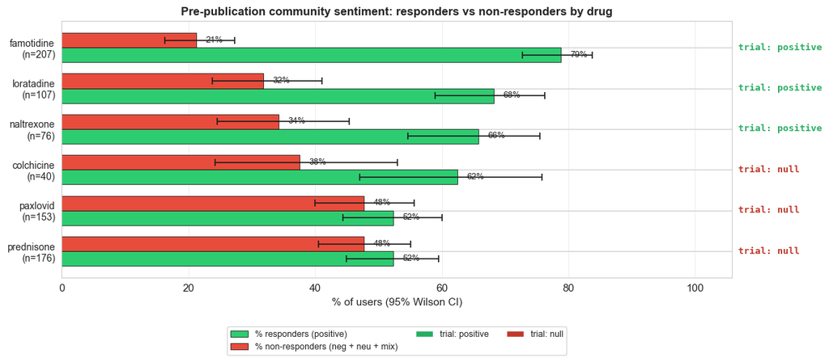

## Data sources and methodology

**Definitions:**

Each user contributes one data point per drug (best-report dedup). All sentiment data is restricted to posts dated *before* the relevant trial's publication date.

Table 2 — Data sources by drug

| Drug | Database | Window | Total posts | Unique users | Treatment reports | Pre-publication cutoff |
| --- | --- | --- | --- | --- | --- | --- |
| famotidine | famotidine_loratadine_prednisone_may_sept_2021 | 2021-05-01 to 2021-09-30 | 88,077 | 207 | 493 | Glynne et al. Oct 2021 |
| loratadine | famotidine_loratadine_prednisone_may_sept_2021 | 2021-05-01 to 2021-09-30 | 88,077 | 107 | 222 | Glynne et al. Oct 2021 |
| prednisone | famotidine_loratadine_prednisone_may_sept_2021 | 2021-05-01 to 2021-09-30 | 88,077 | 176 | 374 | Utrero-Rico et al. 2021 |
| paxlovid | paxlovid_pre_stop_pasc_4mo | 2024-03-01 to 2024-06-06 | 106,889 | 153 | 341 | STOP-PASC Jun 2024 |
| colchicine | colchicine_naltrexone_year_2021 | 2021-01-01 to 2021-12-31 | 217,866 | 40 | 103 | Bassi et al. 2025 |
| naltrexone | colchicine_naltrexone_year_2021 + naltrexone_jan_2022 | 2021-01-01 to 2022-01-30 | 244,036 | 76 | 270 | O'Kelly et al. Jul 2022 |

Total posts = all r/covidlonghaulers posts in the database window. Unique users = distinct users with at least one treatment report for this drug. Treatment reports = total sentiment-tagged mentions (before dedup). Naltrexone spans two databases to maximise pre-publication coverage.

Table 3 — Per-drug response composition (pre-publication data only)

Each row: user-level best-report dedup. Responders = positive; non-responders = negative + neutral + mixed. p-values from two-sided binomial test against 50% null (H₀: responders = non-responders).

[output not shown]